# Lab 4: MEMORIA PRINCIPAL

## Antes de empezar…

…la práctica, copia los ficheros que se encuentran en la carpeta “Materiales” al directorio en el que quieras trabajar. Ahora ya estás preparado para comenzar la práctica.

## Objetivos de la práctica

El objetivo de esta práctica es mostrar los diferentes segmentos en los que se encuentra dividido un proceso en memoria (en este caso en Linux). Se identificarán dichas divisiones y se utilizarán un par de programas parar explorar el espacio de direcciones de un proceso y analizar sus características.

## Entrega y evaluación

El deadline para la entrega de la práctica está especificado en el curso virtual. Cualquier trabajo recibido **fuera del plazo contará como no entregado**. La entrega consistirá en un fichero comprimido **tar.gz** que contenga:

1. La plantilla de “Soluciones.txt” con las respuestas a las preguntas planteadas en las secciones de **Ejercicios**.
2. Para aquellos ejercicios que requieran código fuente, crea una carpeta con el nombre del ejercicio. Esta carpeta deberá contener los ficheros fuente (ficheros *.c y* .h) que resuelvan el ejercicio.
3. Un único fichero makefile en el directorio raíz que compile todos los ejercicios.

Las prácticas que no cumplan el formato de entrega no serán evaluadas completamente. En concreto:

- Si el fichero se ha comprimido usando otro formato **distinto a .tar.gz**: la práctica **no se evaluará**.
- Si falta el fichero “Soluciones.txt” o se entrega con otro formato **distinto a .txt**: las respuestas teóricas contenidas en el mismo **no serán evaluadas**.
- Un programa (con los ficheros *.c y* .h) **sin makefile: no será evaluado**.

# 1.- Espacio de direcciones de un proceso

Examinar el espacio de direcciones virtuales de un proceso en Unix es relativamente fácil. Esto es así porque el mapa de direcciones de cada proceso está representado como un archivo. Todos estos archivos se encuentran dentro del sistema de ficheros de la CPU, que en Linux está montado en la carpeta “/proc”. Este sistema de ficheros contiene toda la información pertinente a la CPU y sirve para configurarla.

Para poder gestionar y acceder a la información de los procesos de forma ordenada, “/proc” contiene una serie de directorios cuyo nombre (siempre numérico) es el PID de cada uno de los procesos que están en ejecución. Dentro de estos directorios puede encontrarse la información del proceso en cuestión. De especial interés para esta práctica es el archivo de nombre “maps”, que nos detalla el espacio de direcciones del proceso.

Por ejemplo, el archivo “/proc/1234/maps” contendrá el espacio de direcciones del proceso 1234, y podríamos ver su contenido mediante la orden `cat`:

```bash
$ cat /proc/1234/maps
```

Además de los directorios cuyo nombre es un número, dentro de “/proc” también hay otro directorio especial, de nombre “self” que apunta siempre al proceso que se esté ejecutando en un momento dado. Es, por tanto, un enlace simbólico al proceso que accede a este archivo. Por tanto, si escribimos:

```bash
$ cat /proc/self/maps
```

Veremos en el terminal el espacio de direcciones del proceso `cat`, que el que se está ejecutando. Al hacerlo obtendremos un resultado estructurado en forma de tabla de seis columnas:

- **Direcciones:** rango de direcciones virtuales
- **Protecciones y modo de compartición:** “r” si se puede leer, “w” si se puede escribir, “x” si se puede ejecutar, “s” si está compartido con otros procesos, y “p” si es privado.
- **Desplazamiento:** si la región de memoria ha sido mapeada desde un fichero, este es el desplazamiento (offset) en el fichero donde el mapeo empieza. Si la memoria no ha sido mapeada desde un fichero, el valor es 0.
- **Dispositivo:** Si la región ha sido mapeada desde un fichero, este campo indica los números mayor y menor del dispositivo.
- **Inode:** Si la región ha sido mapeada desde un fichero, este es su inodo.
- **Nombre de fichero:** Si la región ha sido mapeada desde un fichero, este es el nombre del fichero. El campo se deja en blanco en caso de que la región no haya sido mapeada desde un fichero (región anónima). También existen regiones especialmente importantes que reciben nombres especiales, como *[heap]* o *[stack]*.

Fíjate en que este espacio de direcciones no tiene por qué incluir sólo el programa originalmente invocado, sino también incluye el cargador dinámico, las bibliotecas dinámicas usadas, etc. Este mapa de direcciones presenta todo aquello que el proceso pueda ver.

Si, por ejemplo, leemos el contenido de “/proc/self/maps” con `cat`, el resultado será algo similar a esto:

```
            00400000-0040b000         r-xp 00000000 08:05 812115      /bin/cat
            0060a000-0060b000         r--p 0000a000 08:05 812115      /bin/cat
            0060b000-0060c000         rw-p 0000b000 08:05 812115      /bin/cat
            00a2c000-00a4d000         rw-p 00000000 00:00 0           [heap]
            7f90709d2000-7f90710b5000 r--p 00000000 08:05 6978        /usr/lib/locale/locale-archive
            7f90710b5000-7f907126a000 r-xp 00000000 08:05 655692      /lib/x86_64-linux-gnu/libc-2.15.so
            7f907126a000-7f9071469000 ---p 001b5000 08:05 655692      /lib/x86_64-linux-gnu/libc-2.15.so
            7f9071469000-7f907146d000 r--p 001b4000 08:05 655692      /lib/x86_64-linux-gnu/libc-2.15.so
            7f907146d000-7f907146f000 rw-p 001b8000 08:05 655692      /lib/x86_64-linux-gnu/libc-2.15.so
            7f907146f000-7f9071474000 rw-p 00000000 00:00 0
            7f9071474000-7f9071496000 r-xp 00000000 08:05 655706      lib/x86_64-linux-gnu/ld-2.15.so
            7f907167e000-7f9071681000 rw-p 00000000 00:00 0
            7f9071694000-7f9071696000 rw-p 00000000 00:00 0
            7f9071696000-7f9071697000 r--p 00022000 08:05 655706      /lib/x86_64-linux-gnu/ld-2.15.so
            7f9071697000-7f9071699000 rw-p 00023000 08:05 655706      /lib/x86_64-linux-gnu/ld-2.15.so
            7fffec01f000-7fffec040000 rw-p 00000000 00:00 0           [stack]
```

Puedes ver que la memoria accesible al proceso se divide en diferentes regiones. Para interpretarlas, es útil tener en cuenta el esquema en el que C organiza sus programas:

[figure not shown]

En este caso la primera región contiene el código del programa (segmento *.text*), con permisos de lectura y ejecución (r-xp), extraída del comienzo (dirección 00000000) del fichero “/bin/cat” (*inode* 812115 del dispositivo 08:05). La siguiente región contiene datos de sólo lectura relacionados con los mecanismos de recolocación de las librerias dinámicas/compartidas. Por último, la tercera región contiene los segmentos *.bss* y *.data*, con permisos de lectura/escritura. Les sigue el espacio para *heap*, que no se encuentra respaldado en disco. Podemos comprobar que la última región pertenece a la pila.

Fíjate también en que la región 5 se corresponde a los datos de localización del sistema, que las regiones 6 a 9 cubren las bibliotecas estándar de C, y que en las regiones 11 y 14-15 se encuentra el cargador dinámico. Este último hace posible que el programa enlace correctamente las bibliotecas que va a utilizar.

Para más información puedes consultar el manual del sistema de fichero proc:

```bash
$ man 5 proc
```

## Determinación de direcciones virtuales

A continuación se encuentra el programa “direcciones.c”, que imprime en hexadecimal la dirección de memoria de diversas partes de sí mismo:

direcciones.c:

```c
            #include <stdlib.h>
            #include <stdio.h>
            #include <unistd.h>

            char e1[0x100], e2[0x100];
            char e3[] = "Hola mundo!";
            char* m = "Hola mundo!";

            void escribe(char* texto, void *dir) {
                printf("Dirección de %-4s = %p\n", texto, dir);
            }

            int main(void) {
                char* p1 = malloc(0x1000);
                char* p2 = malloc(0x1000);
                printf("\n");
                escribe("main", main);
                escribe("e1", &e1);
                escribe("e2", &e2);
                escribe("e3", &e3);
                escribe("e3[0]", &e3[0]);
                escribe("m", &m);
                escribe("m[0]", &m[0]);
                escribe("p1", &p1);
                escribe("p2", &p2);
                escribe("*p1", p1);
                escribe("*p2", p2);
                sleep(1000);
            }
```

## Ejercicios

1. Compila el programa y ejecútalo en segundo plano (usando el operador “&”), averigua su número de proceso (usando la orden `ps`), y visualiza el contenido del archivo “maps” que corresponda al proceso. Explica, razonadamente, en qué región (código, datos de sólo lectura, datos de lectura/escritura, *heap*, pila, etc.) se encuentra cada variable y por qué. Fíjate especialmente en la diferencia entre `m[0]` y `e3[0]` ya que te permitirá entender la diferencia entre un `char []` y un `char *`.
2. `objdump` es un programa que nos permite desensamblar un ejecutable y ver sus contenidos en lenguaje ensamblador (en nuestro caso, ensamblador correspondiente a la arquitectura x86). `objdump` es famoso por ser una de las herramientas principales para realizar ingeniería inversa y craks de software. En nuestro caso, vamos a usar `objdump` para profundizar en las regiones de código y datos que has identificado en el ejercicio 1. Utiliza el comando `objdump -D [nombre_binario]` sobre el programa anterior y localiza, documentando la salida obtenida, las siguientes regiones/variables:
- El comienzo de los segmentos de *.data*, *.text* y *.bss*. Basándote en las direcciones obtenidas en el ejercicio 1, especifica que permisos tienen estas regiones.
- Las direcciones de las variables `e1` y `m`, especificando si se encuentran en la región de *.data*, *.text* o *.bss*. Compara las direcciones de memoria obtenidas con `objdump` y las obtenidas en el ejercicio 1. ¿Por qué no aparece la variable `p1` en el dump?
3. ¿Cuál es la diferencia entre la sección de *.data* y la de *.bss*? Explícalo apoyándote en ejemplos que empleen las variables del programa “direcciones.c”.  
   Crea un programa (ejercicio1_3.c) que ubique un `int a` en la sección de .data y un `int b` en la sección de .bss. Comprueba tu respuesta usando `objdump` (adjunta las partes del dump necesarias para justificar tu respuesta).

# 2.- Seguridad en el espacio de direcciones

Los sistemas operativos modernos suelen incluir mecanismos de protección para evitar que un proceso pueda escribir en zonas de memoria sobre las que no se tienen permisos. Estos mecanismos de protección no deben crear falsas expectativas en el usuario: ¡C no realiza comprobación acerca de los límites de los arrays, por lo que salirse de los límites de un array no implica que necesariamente vayamos a obtener un error!

Para ilustrar los mecanismos de protección que proporciona el sistema operativo, considera el programa “test_escritura.c”. Este programa acepta como parámetro una dirección de memoria especificada en decimal, en octal (si empieza por “0”), o en hexadecimal (si empieza por “0x”). A continuación, intenta realizar una escritura en la dirección de memoria indicada. Si no hay ningún error, se concluye que podemos escribir en dicha dirección de memoria.

test_escritura.c:

```c
            #include <unistd.h>
            #include <stdio.h>
            #include <stdlib.h>

            char dato;
            char* dir;

            int main(int argc, char *argv[]) {
                if (argc != 2) {
                    fprintf(stderr, "%s: se necesita una direccion\n", argv[0]);
                    exit(1);
                }
                // obtenemos la dirección de memoria en donde intentaremos
                // escribir de los argumentos de línea de comandos.
                dir  = (char*)strtoul(argv[1], NULL, 0);
                printf ("Probando a escribir en la dirección virtual %p: ", dir);
                fflush(stdout);
                *dir = dato;
                // Si llegamos hasta aquí, no ha habido fallos y tenemos permisos de acceso
                printf("escribible\n");
                sleep(10);
                exit(0);
            }
```

## Ejercicios

1. Utiliza el programa anterior sobre dos zonas de memoria distintas seleccionadas a partir de la salida de “/proc/XXX/maps”. Intenta seleccionar una zona de memoria que no genere errores al ejecutar el programa y otra zona de memoria en la que el programa falle.
   - Lo normal (aunque depende de la distribución que estés usando, sobre todo si es antigua) es que te sea muy difícil elegir la dirección que no genera fallos. Explica qué es lo que hace difícil la elección de una dirección escribible. Éste es un mecanismo de seguridad que implementan la mayor parte de los sistemas operativos modernos (no hace falta que llegues a encontrar la dirección escribible).
   - Describe el error que obtienes cuando la zona no es escribible. ¿Es familiar este tipo de error?
2. **[voluntario]** Los accesos a direcciones no permitidas ocasionan una señal de tipo SIGSEGV. Esta señal podría ser tratada adecuadamente usando la función `signal()` de forma que el programa no finalizase con un error. Modifica el programa anterior para que, en lugar de que el programa falle, imprima por pantalla un mensaje “no escribible”. LLama al programa “ejercicio2_2.c”.

## 2.1 *Ataques de buffer y stack overflow*

Para entender la importancia que tienen los mecanismos de protección de memoria es ilustrativo estudiar uno de los ataques informáticos más conocidos: el *buffer overflow*. Concretamente, estudiaremos los desbordamientos de pila (*stack overflow*).

El buffer overflow se aprovecha de que C no comprueba los límites de los arrays para sobrepasar dichos límites y escribir en otras zonas de memoria. Si la zona de memoria sobreescrita contiene código ejecutable o almacena direcciones de salto es posible alterar el flujo de funcionamiento del programa. Cuando las variables implicadas en el ataque se encuentran en la pila hablamos de *stack overflow*. La siguiente figura intenta ilustrar este tipo de ataque:

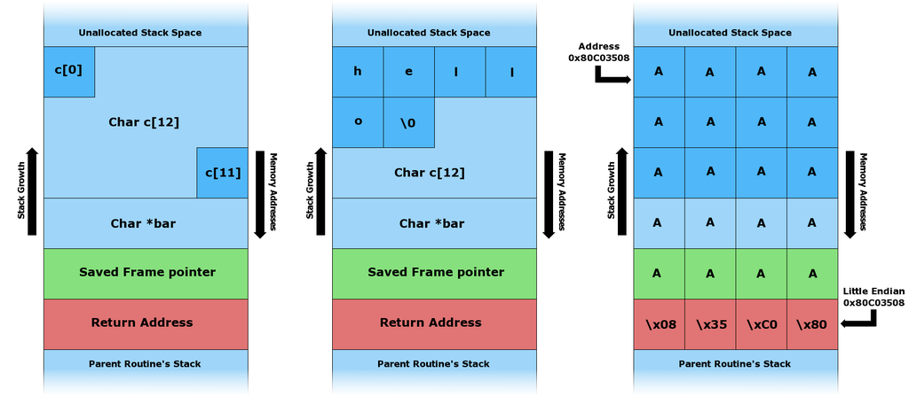

Debemos aclarar que realmente es posible hacer que C realice comprobaciones sobre los límites de los arrays usando las opciones de GCC. Evidentemente, habilitar estas comprobaciones tendrá un impacto importante en el rendimiento del programa. Afortunadamente, los sistemas operativos modernos proporcionan otros mecanismos alternativos que previenen este tipo de ataques. Dos de los más importantes son:

- Aleatorización del layout de memoria (ASLR, Adress Space Layout Randomization). Para evitar que un atacante pueda saltar a una zona de memoria concreta tras realizar un ataque, ASLR aleatoriza las posiciones de memoria de algunas zonas clave de la memoria, como la pila (stack) y el montón (heap). Ejecuta y comprueba el “/proc/XXX/maps” de cualquier proceso un par de veces y comprueba este hecho.
- Uso de *canarios* (canaries, en analogía con el uso de canarios en las minas): son valores conocidos que se colocan entre el buffer y antes de la zona de memoria que se quiera proteger. Gracias a estos valores, es posible monitorizar posibles desbordamientos de buffer.

## Ejercicio [voluntario]

3. **[voluntario]** En este ejercicio, vamos a realizar un stack overflow usando el programa “stack_overflow.c”. Como nuestro sistema operativo incluye los mecanismos de protección discutidos en esta sección, será necesario que los desactivemos momentáneamente:
- Desactivación de ASLR: ejecuta `sudo bash -c 'echo 0 > /proc/sys/kernel/randomize_va_space'`.
- Desactivación de mecanismos de protección del stack: compila el programa con la opción `-fno-stack-protector`: `gcc -fno-stack-protector -z execstack -o stack_overflow stack_overflow.c`. Cuando compiles la función, el compilador te avisará de que no debes usar la función `gets()`. El compilador es sabio y tiene mucha razón: **después de hacer este ejercicio nunca vuelvas a usar *gets()***.

El objetivo del ejercicio es que se imprima por pantalla el mensaje de “soy un hacker”. Para ello, debemos modificar la dirección que se almacena en el puntero a función `fp`. Evidentemente, esta modificación la haremos por medio de un *stack overflow*. Para resolver este ejercicio no puedes modificar el código fuente (imagina que sólo dispones del ejecutable, como en la mayoría de las situaciones de *hacking*). Sigue los siguientes pasos:

1. Como la función a la que debe apuntar `fp` es `yeah`, lo primero que debemos hacer es encontrar la dirección donde se ubica `yeah`. Usa alguna de las herramientas discutidas en los ejercicios anteriores.
2. La dirección obtenida posiblemente asuma que las direcciones empiezan en 0x00. Usa los ficheros en /proc/XXX/maps para comprobar que esta asunción es (muy posiblemente) falsa. Fíjate que, si has desactivado el ASLR con éxito, deberías obtener siempre el mismo layout de memoria. La dirección final de `fp` será la primera de las direcciones del proceso + la obtenida en el paso 1.
3. Una vez sepas la dirección a la que debe apuntar `fp`, debes introducir dicha dirección en `fp` desbordando el buffer `buffer`. Es decir, debes escribir tantos caracteres como sean necesarios y luego escribir la dirección de `yeah`. Para escribir la dirección de forma correcta, recuerda que tu ordenador posiblemente sea little endian. Adicionalmente, para escribir de forma cómoda los datos en el buffer recomendamos hacer uso de un comando similar a

```bash
            # escribe "A" 12 veces (x12)  y lo concatena (.) con los caracteres hexadecimales
            # \x23\x86. Fíjate que el primer carácter se imprime como una #, mientras que el
            # segundo no es imprimible
            perl -e 'print "A"x12 . "\x23\x86"'
```

4. Documenta la solución incluyendo una captura de pantalla con tu comando y la corrrespondiente salida. Recuerda reestablecer el ASLR en tu ordenador.
5. ¿Podría hacerse stack overflow si modificamos las declaraciones de las siguientes formas? Justifica.

Caso 1:

```c
              // resto de código es igual
              int (*fp)();
              char otro_buffer[8];
              char buffer[8];
              // resto de código es igual
```

Caso 2:

```c
              // resto de código es igual
              char buffer[8];
              int (*fp)();
              // resto de código es igual
```

Caso 3:

```c
              // resto de código es igual
              int (*fp)();
              char* buffer = malloc(8 * sizeof(char));
              // resto de código es igual
```